# Multivariate Gaussian Anomaly Detection

Gaussian distributions are widely used in machine learning:

• Central Limit Theorem!

• Gaussians are convenient computationally;

• Mixtures of Gaussians(Multivariate, non Multivariate) are sufficient to approximate a wide range of distributions;

• Closely related to squared loss,an important error measure in statistics.

The distribution should follow Gaussian Distribution.

It(Multivariate Normal/Gaussian distribution, tries to describe, at least approximately, any set of (possibly) correlated real-valued random variables each of which clusters around a mean value.)

If we have a collection(sample) of random vectors X1, X2,...,Xn that are independent and identically distributed, then the sample mean vector, is going to be approximately multivariate normally distributed for large samples.

Say x (data set) is made up of real numbers: Mean is μ and Variance is σ2. σ is also called the standard deviation - specifies the width of the Gaussian probability.

```python
import numpy as np
import pandas as pd

import matplotlib
import matplotlib.pyplot as plt
%matplotlib inline
```

```python
data = pd.read_csv('./creditcard.csv')
print("Size of total data:", len(data))
```

```
Size of total data: 284807
```

```python
normal_data = data.loc[data["Class"] == 0]
fraud_data = data.loc[data["Class"] == 1]
print("Size of normal_data:", len(normal_data))
print("Size of fraud_data:", len(fraud_data))
```

```
Size of normal_data: 284315
Size of fraud_data: 492
```

```python
plt.figure();
```

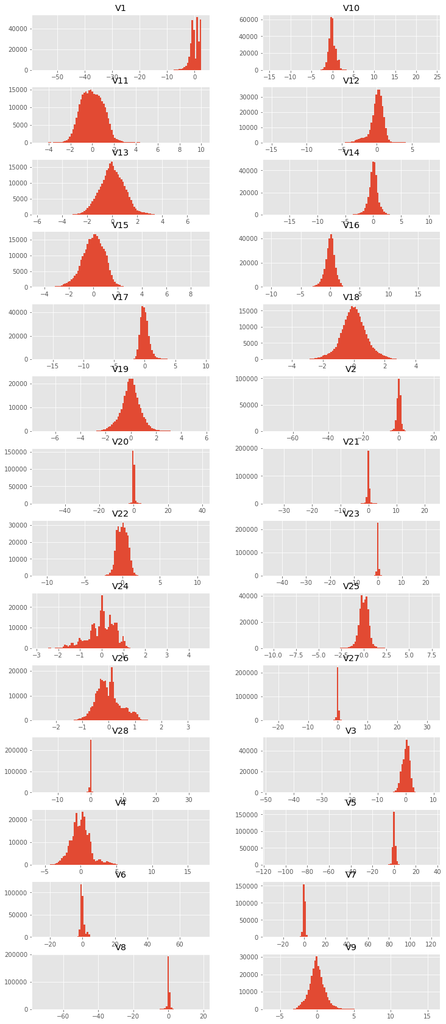

```python
matplotlib.style.use('ggplot')
pca_columns = list(data)[1:-2]
normal_data[pca_columns].hist(stacked=False, bins=100, figsize=(12,30), layout=(14,2));
```

We can see that features can be taken to be Gaussian distributed. Some features have outliers in the normal data Feature V1 seems to behave a little differently and has the most deviance from normal distribution on first sight

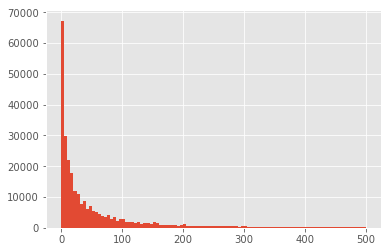

```python
normal_data["Amount"].loc[normal_data["Amount"] < 500].hist(bins=100);
```

```python
print("Mean", normal_data["Amount"].mean())
print("Median", normal_data["Amount"].median())
```

```
Mean 88.29102242225574
Median 22.0
```

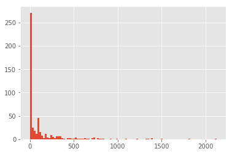

```python
fraud_data["Amount"].hist(bins=100);
```

```python
print("Mean Fraudulent", fraud_data["Amount"].mean())
print("Median Fraudulent", fraud_data["Amount"].median())
```

```
Mean Fraudulent 122.21132113821133
Median Fraudulent 9.25
```

The median is lower but the mean is higher for the fraudulent cases. This suggests there are some high value oriented criminals and some that focus on withdrawals below a limit to avoid detection.

Numpy provides the method to calculate both mean and variance (covariance matrix) efficiently. However, it cannot handle 200000+ amount of data, so we need to write the function explicitly.

Spliting the data into training(X_train and Y_train), cross validation(X_valid, Y_valid) and test(X_test, Y_test) set. The fraudulent cases are split between validation and test set.

```python
normal_pca_data = normal_data[pca_columns]
fraud_pca_data = fraud_data[pca_columns]
num_test = 75000
shuffled_data = normal_pca_data.sample(frac=1)[:-num_test].values

X_train = shuffled_data[:-2*num_test]

X_valid = np.concatenate([shuffled_data[-2*num_test:-num_test], fraud_pca_data[:246]])
y_valid = np.concatenate([np.zeros(num_test), np.ones(246)])

X_test = np.concatenate([shuffled_data[-num_test:], fraud_pca_data[246:]])
y_test = np.concatenate([np.zeros(num_test), np.ones(246)])

print("Size of X:",len(X_train),'   ', len(X_valid), '    ', len(X_test))
print("Size of Y:",len(y_valid), '    ', len(y_test))
print ("Size of normal_pca_data:", len(normal_pca_data))
print ("Size of fraud_pca_data:", len(fraud_pca_data))
print ("Size of fraud_data:", len(fraud_data))
```

```
Size of X: 59315     75246      75246
Size of Y: 75246      75246
Size of normal_pca_data: 284315
Size of fraud_pca_data: 492
Size of fraud_data: 492
```

```python
X_Legit = data.query("Class==0").drop(["Amount","Class","Time"],1)
y_Legit = data.query("Class==0")["Class"]

X_Fraud = data.query("Class==1").drop(["Amount","Class","Time"],1)
y_Fraud = data.query("Class==1")["Class"]

print("Size of X_Legit ",len(X_Legit),'  ', "y_Legit: ", len(y_Legit))
print("Size of X_Fraud ",len(X_Fraud),'  ', "y_Fraud: ", len(y_Fraud))
```

```
Size of X_Legit  284315    y_Legit:  284315
Size of X_Fraud  492    y_Fraud:  492
```

A pair of random variables X and Y , their covariance is defined as: Cov[X, Y ] = E[(X − E[X])(Y − E[Y ])] = E[XY ] − E[X]E[Y ].

The covariance matrix,which we usually denote as Σ, is the n × n matrix whose (i, j)th entry is Cov[Xi, Xj].

General Algorithm: A nx1 mean vector and a nxn covariance matrix.

1.Generate a bunch of uniform random numbers and convert them into a Gaussian random number with a known mean and standard deviation.

2.Do the previous step n times to generate an n-dimensional Gaussian vector with a known mean and covariance matrix.

3.Transform this random Gaussian vector so that it lines up with the mean and covariance provided by the user.